# 2024 NH3-loss Statistical Models, outdoor only - sqrt

## Model A_Irrigation

Irrigation was modeled as a binomial variable due to heavy zero-inflation in the data.

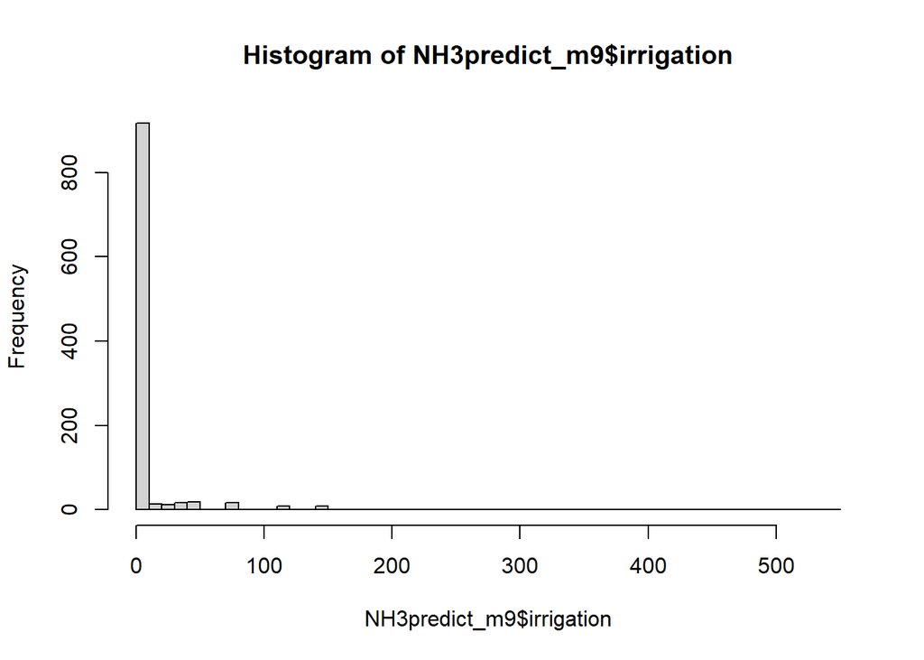

The number of observations in total in each category can be seen below:

```
##   irrigation_cat   N
## 1              0 898
## 2              1 113
```

```r
# Model
m9_lm <- lm(sqrt(NH3loss+4) ~ irrigation_cat + offset(M1_fit),
            weights=Weight,
            data=NH3predict_m9)
```

The check for normality and heteroscedasticity of errors can be seen below:

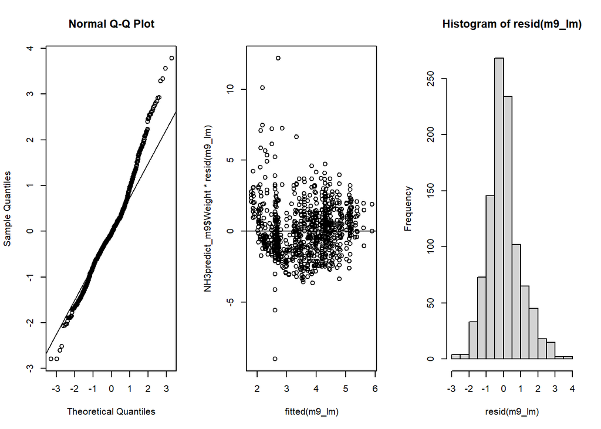

There was no effect of irrigation on NH3-loss (F(1, 1009) =0.27, p = 0.601).

```
##
## Call:
## lm(formula = sqrt(NH3loss + 4) ~ irrigation_cat + offset(M1_fit),
##     data = NH3predict_m9, weights = Weight)
##
## Weighted Residuals:
##     Min      1Q  Median      3Q     Max
## -4.8480 -0.8140 -0.0927  0.7121  6.7880
##
## Coefficients:
##                  Estimate Std. Error t value Pr(>|t|)
## (Intercept)      0.005472   0.026116   0.210    0.834
## irrigation_cat1 -0.039400   0.075254  -0.524    0.601
##
## Residual standard error: 1.245 on 1009 degrees of freedom
## Multiple R-squared:  0.0002716,  Adjusted R-squared:  -0.0007192
## F-statistic: 0.2741 on 1 and 1009 DF,  p-value: 0.6007
```

Adjusted R2-value of the model was -7.2^{-4}, and multiple R2 was 2.7^{-4}. The negative adjusted R2-value indicates that the amount of variation accounted for by irrigation is negligible. In practice, it explain no variation in the data.

The marginal means for NH3 loss in no-irrigation and irrigation categories can be seen below.

```
##   irrigation_cat   emmean         SE   df lower.CL upper.CL
## 1              0 3.564305 0.02611581 1009 3.513057 3.615552
## 2              1 3.524904 0.07057688 1009 3.386410 3.663399
```

```
## `height` was translated to `width`.
```

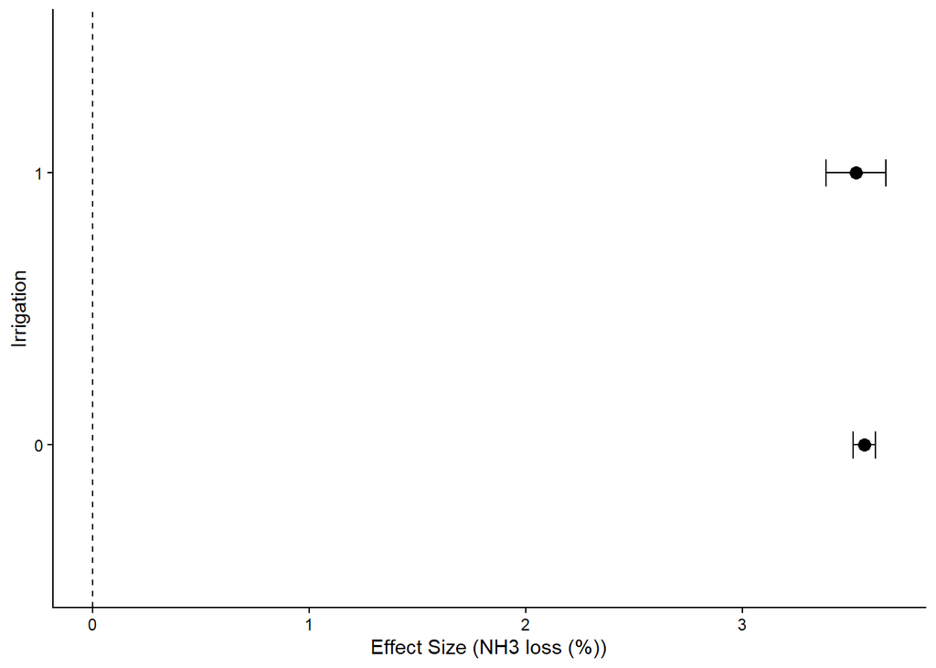

## Model A_Water input

Daily water input (mm) consists of irrigation and rainfall.

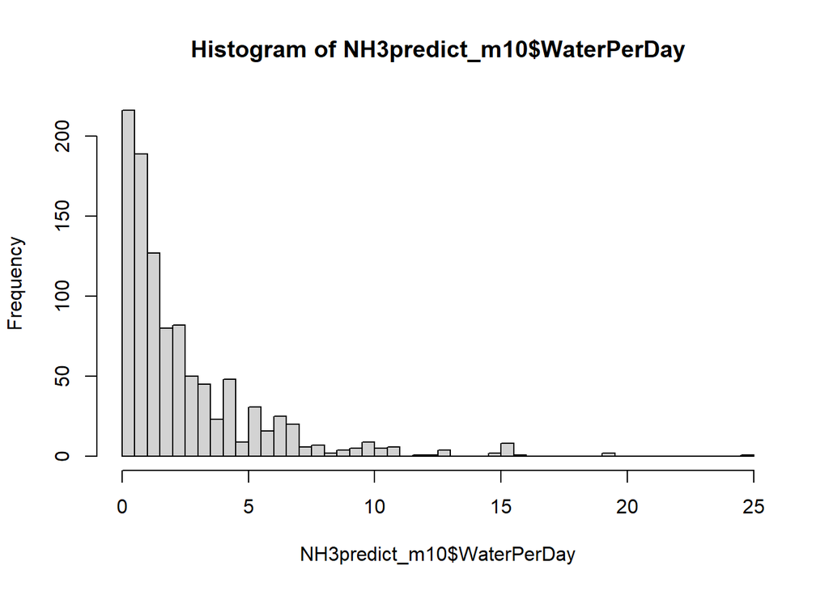

```r
#  Model
m10_lm <- lm(sqrt(NH3loss+4) ~ WaterPerDay + offset(M1_fit),
             weights=Weight,
             data=NH3predict_m10)
```

Heteroscedasticity and normality of erros were as below:

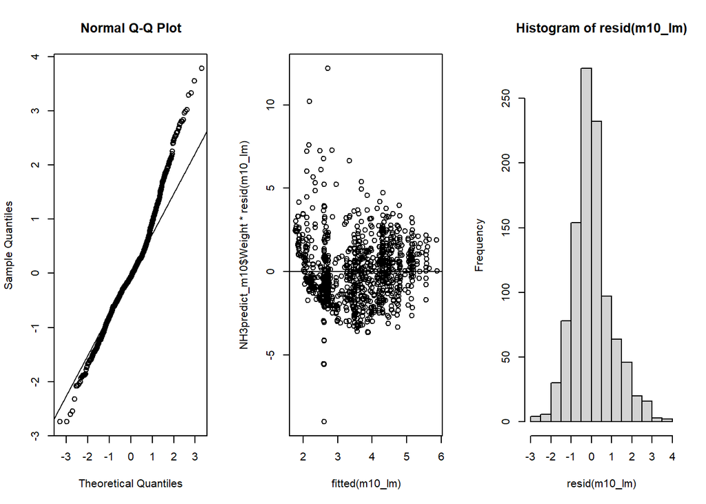

There was no effect of water input on NH3-loss (F(1, 1023) =0.9, p = 0.342).

```
##
## Call:
## lm(formula = sqrt(NH3loss + 4) ~ WaterPerDay + offset(M1_fit),
##     data = NH3predict_m10, weights = Weight)
##
## Weighted Residuals:
##     Min      1Q  Median      3Q     Max
## -4.8448 -0.8497 -0.1189  0.7152  6.7914
##
## Coefficients:
##              Estimate Std. Error t value Pr(>|t|)
## (Intercept)  0.014124   0.032738   0.431    0.666
## WaterPerDay -0.007766   0.008172  -0.950    0.342
##
## Residual standard error: 1.271 on 1023 degrees of freedom
## Multiple R-squared:  0.000882,   Adjusted R-squared:  -9.469e-05
## F-statistic: 0.903 on 1 and 1023 DF,  p-value: 0.3422
```

```
## Analysis of Variance Table
##
## Response: sqrt(NH3loss + 4)
##               Df  Sum Sq Mean Sq F value Pr(>F)
## WaterPerDay    1    1.46  1.4599   0.903 0.3422
## Residuals   1023 1653.85  1.6167
```

Adjusted R2-value of the model was -9^{-5}, and multiple R2 was 8.8^{-4}. The negative adjusted R2-value indicates that the amount of variation accounted for by daily water input is negligible. In practice, it explain no variation in the data.

Figure below shows a linear approximation of the effect of daily water input (mm) on NH3-emissions (linear slope back-transformed from the square-root scale).

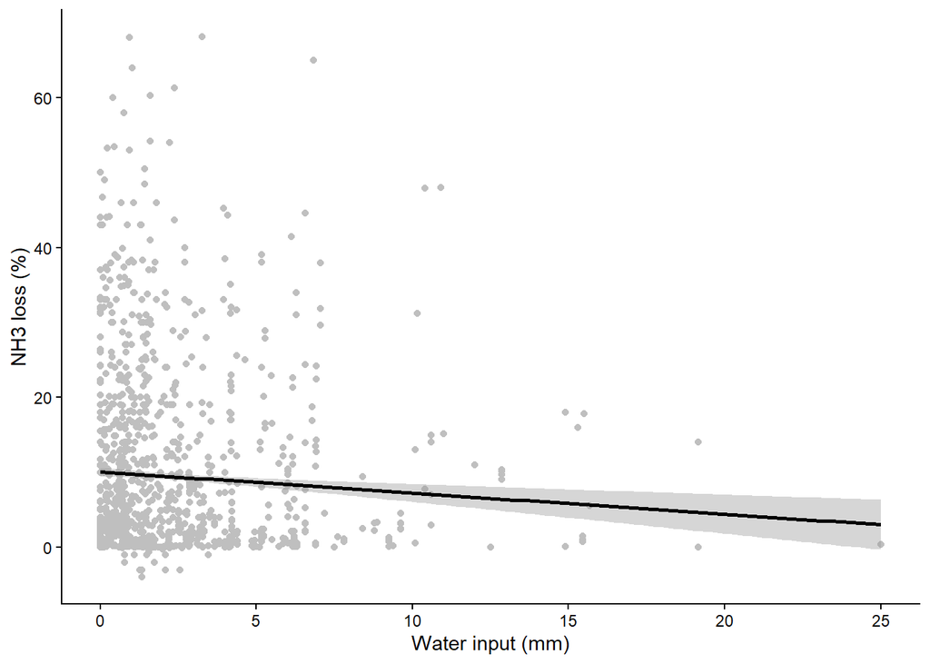

## Model A_Experiment duration

Duration of the experiment (days).

```
##    Min. 1st Qu.  Median    Mean 3rd Qu.    Max.
##     3.0    10.0    18.0    20.2    25.0   120.0
```

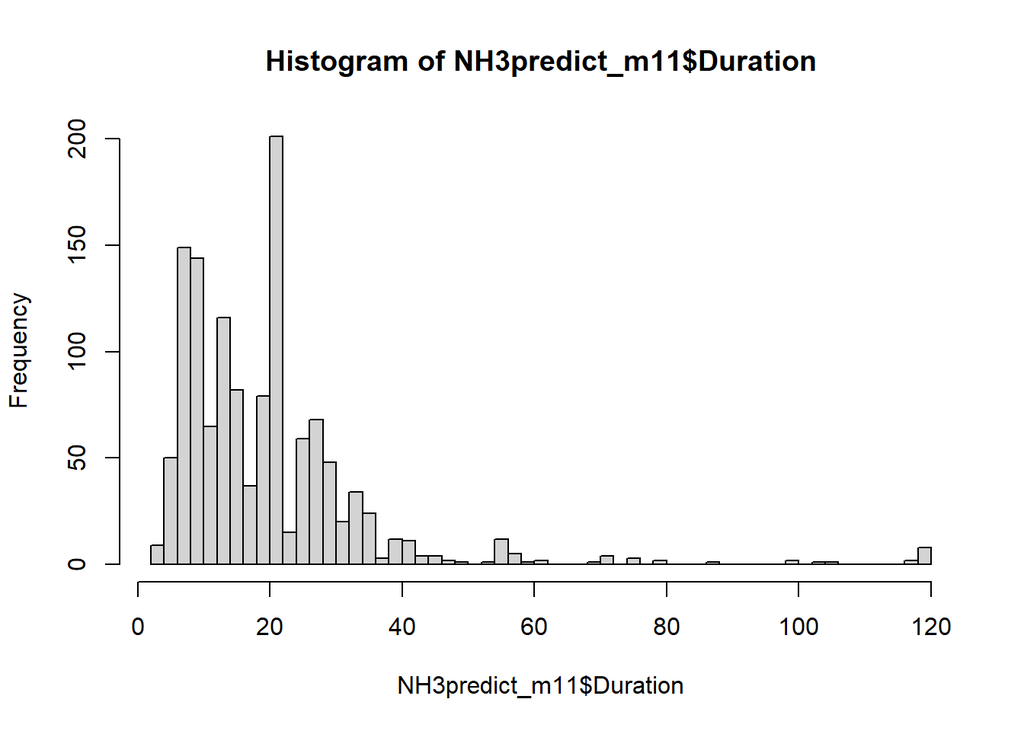

```r
#  Model
m11_lm <- lm(sqrt(NH3loss+4) ~ Duration + offset(M1_fit),
             weights=Weight,
             data=NH3predict_m11)
```

Heteroscedasticity and normality of erros were as below:

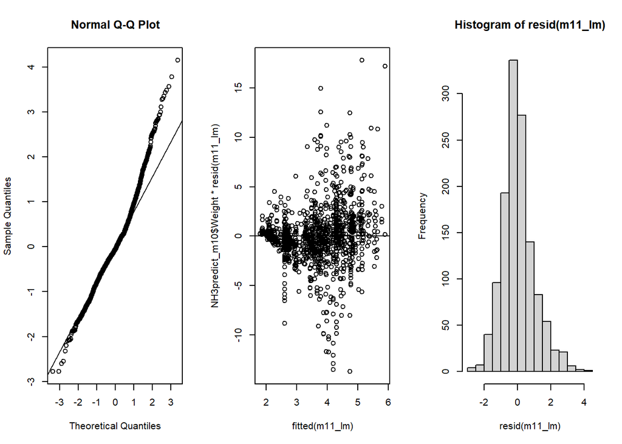

There was no effect of duration of the experiment on NH3-loss (F(1, 1281) =0.18, p = 0.667).

```
##
## Call:
## lm(formula = sqrt(NH3loss + 4) ~ Duration + offset(M1_fit), data = NH3predict_m11,
##     weights = Weight)
##
## Weighted Residuals:
##     Min      1Q  Median      3Q     Max
## -4.8378 -0.8358 -0.1009  0.7399  6.7891
##
## Coefficients:
##               Estimate Std. Error t value Pr(>|t|)
## (Intercept) -0.0145160  0.0385648  -0.376    0.707
## Duration     0.0006915  0.0016080   0.430    0.667
##
## Residual standard error: 1.265 on 1281 degrees of freedom
## Multiple R-squared:  0.0001443,  Adjusted R-squared:  -0.0006362
## F-statistic: 0.1849 on 1 and 1281 DF,  p-value: 0.6673
```

```
## Analysis of Variance Table
##
## Response: sqrt(NH3loss + 4)
##             Df Sum Sq Mean Sq F value Pr(>F)
## Duration     1    0.3 0.29613  0.1849 0.6673
## Residuals 1281 2051.4 1.60144
```

Adjusted R2-value of the model was -6.4^{-4}, and multiple R2 was 1.4^{-4}. The negative adjusted R2-value indicates that the amount of variation accounted for by duration of the experiment is negligible. In practice, it explain no variation in the data.

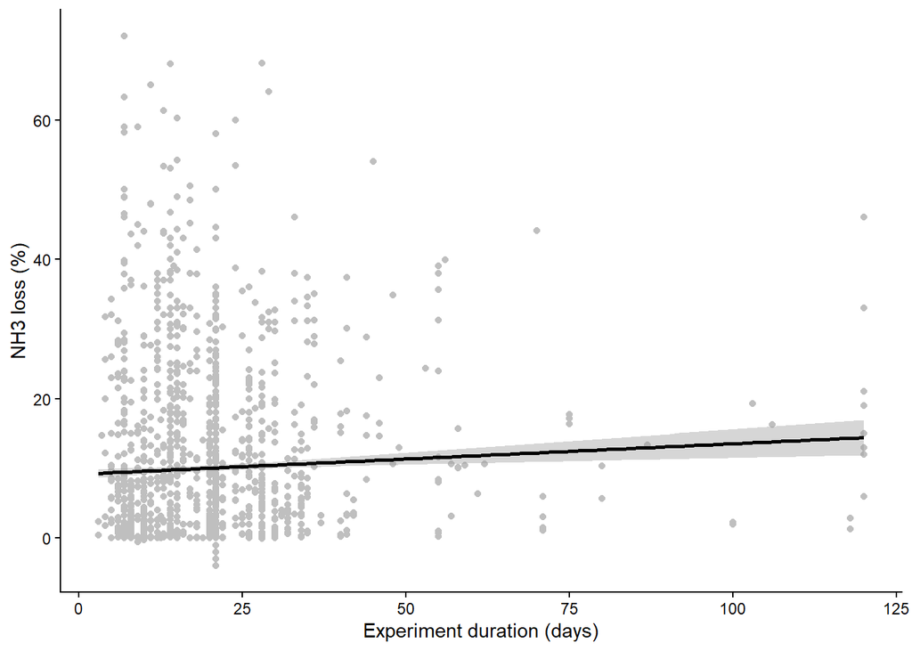

## Combined model with all variables of effect

### Model LO1_Base model and pH

```
## Type III Analysis of Variance Table with Satterthwaite's method
##                   Sum Sq Mean Sq NumDF   DenDF  F value    Pr(>F)
## Fertiliser        572.30 190.766     3 1310.14 114.4470 < 2.2e-16 ***
## Application        52.61  17.536     3 1254.98  10.5202 7.780e-07 ***
## Method             38.69   6.449     6  205.23   3.8688  0.001112 **
## pH_cat             51.14  51.135     1 1292.57  30.6779 3.686e-08 ***
## Fertiliser:pH_cat 128.01  42.670     3 1307.40  25.5991 4.297e-16 ***
## ---
## Signif. codes:  0 '***' 0.001 '**' 0.01 '*' 0.05 '.' 0.1 ' ' 1
```

```
## Linear mixed model fit by REML. t-tests use Satterthwaite's method [
## lmerModLmerTest]
## Formula: sqrt(NH3loss + 4) ~ Fertiliser + Application + Method + pH_cat +
##     Fertiliser:pH_cat + (1 | Ref)
##    Data: NH3predict_mALL
## Weights: Weight
## Control: lmerControl(optimizer = "bobyqa")
##
## REML criterion at convergence: 3839.2
##
## Scaled residuals:
##     Min      1Q  Median      3Q     Max
## -3.6357 -0.5747 -0.0943  0.5324  5.3363
##
## Random effects:
##  Groups   Name        Variance Std.Dev.
##  Ref      (Intercept) 0.7571   0.8701
##  Residual             1.6668   1.2911
## Number of obs: 1355, groups:  Ref, 157
##
## Fixed effects:
##                                     Estimate Std. Error         df t value
## (Intercept)                          4.42053    0.17784  267.25478  24.857
## FertiliserUAN                       -0.90927    0.22133 1318.91163  -4.108
## Fertiliserammonium+1                -1.59455    0.13688 1327.34946 -11.649
## Fertiliserammonium+2                -1.78098    0.08276 1307.69279 -21.520
## ApplicationIncorporated             -0.55046    0.10587 1334.22523  -5.200
## ApplicationInjected                 -0.66804    0.28266 1327.57262  -2.363
## ApplicationLiquid                   -0.02910    0.16391 1126.23027  -0.178
## Method15N                           -1.16613    0.46727  992.09083  -2.496
## MethodClosed chamber                -0.51481    0.23064  173.28925  -2.232
## MethodDrager-Tube                   -0.73858    0.35805  122.42494  -2.063
## MethodSemi-open                      0.09744    0.26940  175.35034   0.362
## MethodVentilated chambers           -0.50918    0.20992  382.14723  -2.426
## MethodWindtunnel                     0.32431    0.27335  211.32136   1.186
## pH_catchalky                        -0.07954    0.10644 1201.78426  -0.747
## FertiliserUAN:pH_catchalky           0.69816    0.25858 1323.17795   2.700
## Fertiliserammonium+1:pH_catchalky    1.77130    0.20571 1312.46651   8.611
## Fertiliserammonium+2:pH_catchalky    0.33035    0.16405 1296.55566   2.014
##                                   Pr(>|t|)
## (Intercept)                        < 2e-16 ***
## FertiliserUAN                     4.23e-05 ***
## Fertiliserammonium+1               < 2e-16 ***
## Fertiliserammonium+2               < 2e-16 ***
## ApplicationIncorporated           2.31e-07 ***
## ApplicationInjected                0.01825 *
## ApplicationLiquid                  0.85912
## Method15N                          0.01273 *
## MethodClosed chamber               0.02689 *
## MethodDrager-Tube                  0.04125 *
## MethodSemi-open                    0.71803
## MethodVentilated chambers          0.01575 *
## MethodWindtunnel                   0.23679
## pH_catchalky                       0.45502
## FertiliserUAN:pH_catchalky         0.00702 **
## Fertiliserammonium+1:pH_catchalky  < 2e-16 ***
## Fertiliserammonium+2:pH_catchalky  0.04425 *
## ---
## Signif. codes:  0 '***' 0.001 '**' 0.01 '*' 0.05 '.' 0.1 ' ' 1
```

```
##
## Correlation matrix not shown by default, as p = 17 > 12.
## Use print(x, correlation=TRUE)  or
##     vcov(x)        if you need it
```

```
##            R2m       R2c
## [1,] 0.1823593 0.4377492
```

Total observations = 1355

Model LO1 explains 43.77 % of the variation in the data (conditional R2), with the fixed effects explaining 18.24 % (marginal R2). The R2-values for linear mixed effects model were calculated according to Nagakawa & Schielzeth (2013).

```
##                Factor               Level    Effect       SE        df
## 1          Fertiliser               urea+ 15.541107 1.577229  377.7758
## 2          Fertiliser                 UAN  8.328997 1.961244 1310.8897
## 3          Fertiliser          ammonium+1  3.986176 1.225413  773.5242
## 4          Fertiliser          ammonium+2  2.967226 1.007987  507.4514
## 5         Application           Broadcast 15.541107 1.577229  377.7758
## 6         Application        Incorporated 10.977436 1.578073  610.0163
## 7         Application            Injected 10.081163 2.526309 2646.1649
## 8         Application              Liquid 15.284682 2.016273  672.6392
## 9              Method            Micromet 15.541107 1.577229  377.7758
## 10             Method                 15N  6.591105 2.837578 4809.7763
## 11             Method      Closed chamber 11.254636 1.255047  216.3887
## 12             Method         Drager-Tube  9.556784 2.378294  133.3877
## 13             Method           Semi-open 16.412046 1.876236  192.6491
## 14             Method Ventilated chambers 11.298695 1.281372  314.9225
```

[output cut: 37 more lines]

### Model LO2_Base model, pH, and Application rate

```
## Type III Analysis of Variance Table with Satterthwaite's method
##                   Sum Sq Mean Sq NumDF   DenDF F value    Pr(>F)
## Fertiliser        472.53 157.512     3 1262.39 94.8646 < 2.2e-16 ***
## Application        53.20  17.732     3 1184.52 10.6793 6.276e-07 ***
## Method             39.70   6.617     6  202.43  3.9851 0.0008586 ***
## pH_cat             48.86  48.860     1 1277.43 29.4271 6.938e-08 ***
## Application.rate   21.16  21.157     1 1059.90 12.7421 0.0003735 ***
## Fertiliser:pH_cat 122.16  40.720     3 1268.41 24.5246 1.990e-15 ***
## ---
## Signif. codes:  0 '***' 0.001 '**' 0.01 '*' 0.05 '.' 0.1 ' ' 1
```

```
## Linear mixed model fit by REML. t-tests use Satterthwaite's method [
## lmerModLmerTest]
## Formula: sqrt(NH3loss + 4) ~ Fertiliser + Application + Method + pH_cat +
##     Fertiliser:pH_cat + Application.rate + (1 | Ref)
##    Data: NH3predict_mALL2
## Weights: Weight
## Control: lmerControl(optimizer = "bobyqa")
##
## REML criterion at convergence: 3746.3
##
## Scaled residuals:
##     Min      1Q  Median      3Q     Max
## -3.6474 -0.5819 -0.0723  0.5446  5.1510
##
## Random effects:
##  Groups   Name        Variance Std.Dev.
##  Ref      (Intercept) 0.8142   0.9024
##  Residual             1.6604   1.2886
## Number of obs: 1317, groups:  Ref, 152
##
## Fixed effects:
##                                     Estimate Std. Error         df t value
## (Intercept)                        4.146e+00  2.020e-01  3.034e+02  20.528
## FertiliserUAN                     -9.390e-01  2.289e-01  1.270e+03  -4.102
## Fertiliserammonium+1              -1.562e+00  1.396e-01  1.287e+03 -11.188
## Fertiliserammonium+2              -1.763e+00  8.348e-02  1.263e+03 -21.115
## ApplicationIncorporated           -5.599e-01  1.071e-01  1.299e+03  -5.227
## ApplicationInjected               -6.494e-01  2.851e-01  1.287e+03  -2.277
## ApplicationLiquid                  4.507e-02  1.828e-01  9.803e+02   0.247
## Method15N                         -1.217e+00  4.722e-01  9.273e+02  -2.578
## MethodClosed chamber              -5.962e-01  2.407e-01  1.657e+02  -2.477
## MethodDrager-Tube                 -6.863e-01  3.704e-01  1.192e+02  -1.853
## MethodSemi-open                    9.928e-02  2.784e-01  1.706e+02   0.357
## MethodVentilated chambers         -5.609e-01  2.156e-01  3.870e+02  -2.602
## MethodWindtunnel                   2.959e-01  2.807e-01  2.072e+02   1.054
## pH_catchalky                      -8.795e-02  1.088e-01  1.195e+03  -0.808
## Application.rate                   2.553e-03  7.152e-04  1.060e+03   3.570
## FertiliserUAN:pH_catchalky         7.087e-01  2.678e-01  1.278e+03   2.647
## Fertiliserammonium+1:pH_catchalky  1.756e+00  2.082e-01  1.271e+03   8.437
## Fertiliserammonium+2:pH_catchalky  3.531e-01  1.767e-01  1.265e+03   1.999
##                                   Pr(>|t|)
## (Intercept)                        < 2e-16 ***
## FertiliserUAN                     4.36e-05 ***
## Fertiliserammonium+1               < 2e-16 ***
## Fertiliserammonium+2               < 2e-16 ***
## ApplicationIncorporated           2.01e-07 ***
## ApplicationInjected               0.022922 *
## ApplicationLiquid                 0.805276
## Method15N                         0.010078 *
## MethodClosed chamber              0.014238 *
## MethodDrager-Tube                 0.066398 .
## MethodSemi-open                   0.721867
## MethodVentilated chambers         0.009625 **
## MethodWindtunnel                  0.293037
## pH_catchalky                      0.419174
## Application.rate                  0.000374 ***
## FertiliserUAN:pH_catchalky        0.008230 **
## Fertiliserammonium+1:pH_catchalky  < 2e-16 ***
## Fertiliserammonium+2:pH_catchalky 0.045838 *
## ---
## Signif. codes:  0 '***' 0.001 '**' 0.01 '*' 0.05 '.' 0.1 ' ' 1
```

```
##
## Correlation matrix not shown by default, as p = 18 > 12.
## Use print(x, correlation=TRUE)  or
##     vcov(x)        if you need it
```

```
##            R2m       R2c
## [1,] 0.1905383 0.4568817
```

Model LO2 explains 45.69 % of the variation in the data (conditional R2), with the fixed effects explaining 19.05 % (marginal R2). Total observations = 1317

### Model LO3_Base model, pH and temperature

```
## Type III Analysis of Variance Table with Satterthwaite's method
##                   Sum Sq Mean Sq NumDF   DenDF F value    Pr(>F)
## Fertiliser        340.77 113.591     3 1004.86 71.0589 < 2.2e-16 ***
## Application        46.10  15.368     3  963.56  9.6139 2.946e-06 ***
## Method             50.16   8.360     6  160.72  5.2297 6.049e-05 ***
## pH_cat             36.57  36.566     1 1008.64 22.8743 1.987e-06 ***
## AirTemperature     28.78  28.778     1  991.30 18.0029 2.412e-05 ***
## Fertiliser:pH_cat  57.77  19.257     3 1002.44 12.0465 9.455e-08 ***
## ---
## Signif. codes:  0 '***' 0.001 '**' 0.01 '*' 0.05 '.' 0.1 ' ' 1
```

```
## Linear mixed model fit by REML. t-tests use Satterthwaite's method [
## lmerModLmerTest]
## Formula: sqrt(NH3loss + 4) ~ Fertiliser + Application + Method + pH_cat +
##     Fertiliser:pH_cat + AirTemperature + (1 | Ref)
##    Data: NH3predict_mALL3
## Weights: Weight
## Control: lmerControl(optimizer = "bobyqa")
##
## REML criterion at convergence: 2846.5
##
## Scaled residuals:
##     Min      1Q  Median      3Q     Max
## -3.9217 -0.5862 -0.0543  0.5366  5.4324
##
## Random effects:
##  Groups   Name        Variance Std.Dev.
##  Ref      (Intercept) 0.7266   0.8524
##  Residual             1.5985   1.2643
## Number of obs: 1034, groups:  Ref, 116
##
## Fixed effects:
##                                     Estimate Std. Error         df t value
## (Intercept)                        4.106e+00  2.109e-01  2.315e+02  19.465
## FertiliserUAN                     -9.762e-01  2.343e-01  1.011e+03  -4.166
## Fertiliserammonium+1              -1.354e+00  1.720e-01  1.016e+03  -7.872
## Fertiliserammonium+2              -1.684e+00  8.763e-02  9.899e+02 -19.212
## ApplicationIncorporated           -5.345e-01  1.114e-01  1.014e+03  -4.799
## ApplicationInjected               -6.035e-01  2.824e-01  1.004e+03  -2.137
## ApplicationLiquid                  1.633e-01  1.935e-01  8.965e+02   0.844
## Method15N                         -1.029e+00  5.111e-01  8.006e+02  -2.012
## MethodClosed chamber              -6.589e-01  2.699e-01  1.224e+02  -2.441
## MethodDrager-Tube                 -1.071e+00  3.784e-01  9.235e+01  -2.831
## MethodSemi-open                   -1.145e-01  3.028e-01  1.372e+02  -0.378
## MethodVentilated chambers         -9.145e-01  2.329e-01  3.172e+02  -3.926
## MethodWindtunnel                   2.288e-01  2.842e-01  1.668e+02   0.805
## pH_catchalky                      -7.164e-02  1.133e-01  9.680e+02  -0.632
## AirTemperature                     2.432e-02  5.732e-03  9.913e+02   4.243
## FertiliserUAN:pH_catchalky         8.080e-01  2.747e-01  1.005e+03   2.942
## Fertiliserammonium+1:pH_catchalky  1.409e+00  2.574e-01  1.014e+03   5.475
## Fertiliserammonium+2:pH_catchalky  3.854e-01  1.907e-01  9.943e+02   2.021
##                                   Pr(>|t|)
## (Intercept)                        < 2e-16 ***
## FertiliserUAN                     3.36e-05 ***
## Fertiliserammonium+1              8.93e-15 ***
## Fertiliserammonium+2               < 2e-16 ***
## ApplicationIncorporated           1.84e-06 ***
## ApplicationInjected               0.032820 *
## ApplicationLiquid                 0.398824
## Method15N                         0.044536 *
## MethodClosed chamber              0.016069 *
## MethodDrager-Tube                 0.005688 **
## MethodSemi-open                   0.705829
## MethodVentilated chambers         0.000106 ***
## MethodWindtunnel                  0.421953
## pH_catchalky                      0.527329
## AirTemperature                    2.41e-05 ***
## FertiliserUAN:pH_catchalky        0.003337 **
## Fertiliserammonium+1:pH_catchalky 5.53e-08 ***
## Fertiliserammonium+2:pH_catchalky 0.043549 *
## ---
## Signif. codes:  0 '***' 0.001 '**' 0.01 '*' 0.05 '.' 0.1 ' ' 1
```

```
##
## Correlation matrix not shown by default, as p = 18 > 12.
## Use print(x, correlation=TRUE)  or
##     vcov(x)        if you need it
```

```
##            R2m      R2c
## [1,] 0.2000459 0.450018
```

Total observations = 1034

Model LO3 explains 45 % of the variation in the data (conditional R2), with the fixed effects explaining 20 % (marginal R2). The R2-values for linear mixed effects model were calculated according to Nagakawa & Schielzeth (2013).

### Model LO4_Base variables, pH, application rate, and temperature

```r
mALL4_lmer <- lmer(sqrt(NH3loss+4) ~ Fertiliser + Application + Method  +
                    pH_cat + Fertiliser:pH_cat +
                    Application.rate + AirTemperature +
                    (1|Ref),
                   weights=Weight,
                   control=lmerControl(optimizer="bobyqa"),
                   data=NH3predict_mALL4)
```

Total observations = 1025

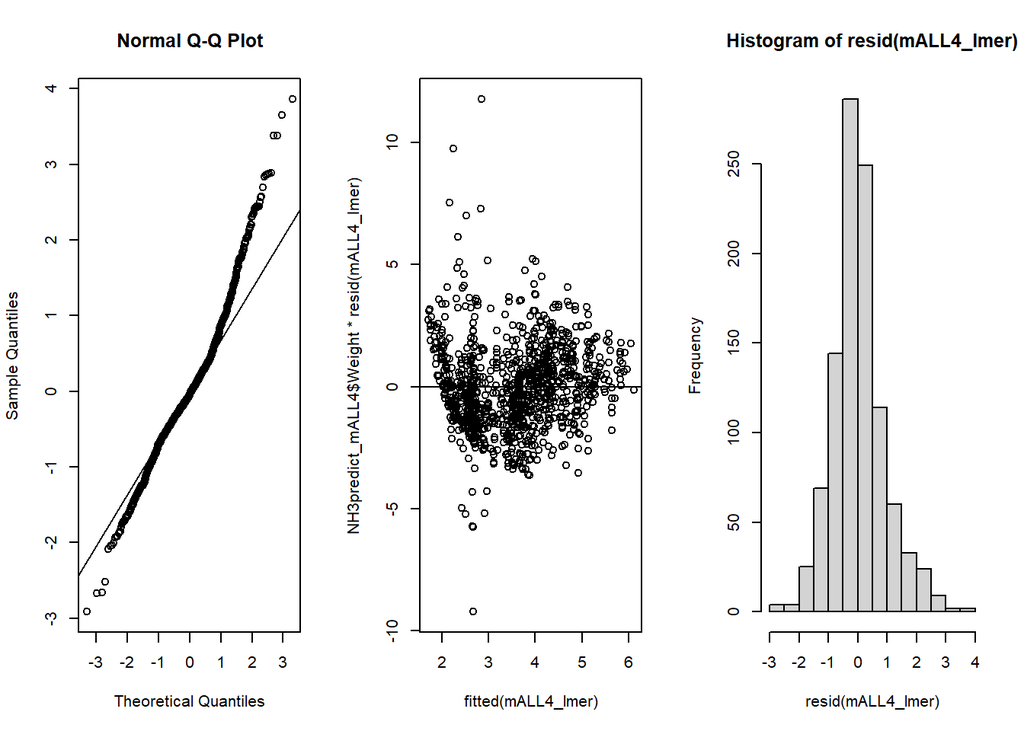

```
## Type III Analysis of Variance Table with Satterthwaite's method
##                   Sum Sq Mean Sq NumDF   DenDF F value    Pr(>F)
## Fertiliser        328.27 109.423     3  992.88 69.4623 < 2.2e-16 ***
## Application        47.99  15.998     3  962.18 10.1553 1.374e-06 ***
## Method             48.20   8.033     6  162.09  5.0991 8.019e-05 ***
## pH_cat             33.39  33.388     1 1003.04 21.1947 4.681e-06 ***
## Application.rate   18.13  18.130     1  745.14 11.5089 0.0007292 ***
## AirTemperature     25.37  25.371     1  992.67 16.1057 6.441e-05 ***
## Fertiliser:pH_cat  50.61  16.869     3  988.90 10.7086 6.260e-07 ***
## ---
## Signif. codes:  0 '***' 0.001 '**' 0.01 '*' 0.05 '.' 0.1 ' ' 1
```

```
## Linear mixed model fit by REML. t-tests use Satterthwaite's method [
## lmerModLmerTest]
## Formula: sqrt(NH3loss + 4) ~ Fertiliser + Application + Method + pH_cat +
##     Fertiliser:pH_cat + Application.rate + AirTemperature + (1 |      Ref)
##    Data: NH3predict_mALL4
## Weights: Weight
## Control: lmerControl(optimizer = "bobyqa")
##
## REML criterion at convergence: 2826.8
##
## Scaled residuals:
##     Min      1Q  Median      3Q     Max
## -3.9491 -0.5760 -0.0574  0.5519  5.2254
##
## Random effects:
##  Groups   Name        Variance Std.Dev.
##  Ref      (Intercept) 0.8013   0.8952
##  Residual             1.5753   1.2551
## Number of obs: 1025, groups:  Ref, 114
##
## Fixed effects:
##                                     Estimate Std. Error         df t value
## (Intercept)                        3.794e+00  2.348e-01  2.497e+02  16.157
## FertiliserUAN                     -9.549e-01  2.340e-01  1.005e+03  -4.082
## Fertiliserammonium+1              -1.293e+00  1.774e-01  1.006e+03  -7.286
## Fertiliserammonium+2              -1.663e+00  8.801e-02  9.717e+02 -18.893
## ApplicationIncorporated           -5.467e-01  1.112e-01  1.000e+03  -4.918
## ApplicationInjected               -6.217e-01  2.813e-01  9.883e+02  -2.210
## ApplicationLiquid                  1.761e-01  1.938e-01  9.171e+02   0.909
## Method15N                         -1.000e+00  5.136e-01  7.562e+02  -1.948
## MethodClosed chamber              -6.602e-01  2.789e-01  1.184e+02  -2.367
## MethodDrager-Tube                 -9.828e-01  3.940e-01  9.095e+01  -2.494
## MethodSemi-open                   -8.423e-02  3.135e-01  1.339e+02  -0.269
## MethodVentilated chambers         -9.697e-01  2.390e-01  3.308e+02  -4.057
## MethodWindtunnel                   2.229e-01  2.919e-01  1.656e+02   0.764
## pH_catchalky                      -6.193e-02  1.137e-01  9.772e+02  -0.545
## Application.rate                   2.884e-03  8.500e-04  7.451e+02   3.392
## AirTemperature                     2.304e-02  5.742e-03  9.927e+02   4.013
## FertiliserUAN:pH_catchalky         7.757e-01  2.737e-01  9.908e+02   2.834
## Fertiliserammonium+1:pH_catchalky  1.333e+00  2.605e-01  1.002e+03   5.117
```

[output cut: 8 more lines]

```
## ApplicationLiquid                 0.363697
## Method15N                         0.051794 .
## MethodClosed chamber              0.019557 *
## MethodDrager-Tube                 0.014429 *
## MethodSemi-open                   0.788591
## MethodVentilated chambers         6.20e-05 ***
## MethodWindtunnel                  0.446220
## pH_catchalky                      0.585962
## Application.rate                  0.000729 ***
## AirTemperature                    6.44e-05 ***
## FertiliserUAN:pH_catchalky        0.004686 **
## Fertiliserammonium+1:pH_catchalky 3.72e-07 ***
## Fertiliserammonium+2:pH_catchalky 0.048518 *
## ---
## Signif. codes:  0 '***' 0.001 '**' 0.01 '*' 0.05 '.' 0.1 ' ' 1
```

```
##
## Correlation matrix not shown by default, as p = 19 > 12.
## Use print(x, correlation=TRUE)  or
##     vcov(x)        if you need it
```

```
##            R2m       R2c
## [1,] 0.2087542 0.4755343
```

Model LO4 explains 47.55 % of the variation in the data (conditional R2), with the fixed effects explaining 20.88 % (marginal R2).

```
##                Factor               Level    Effect       SE         df
## 1          Fertiliser               urea+ 16.064094 1.809048  283.92977
## 2          Fertiliser                 UAN  8.421133 2.125893  933.39982
## 3          Fertiliser          ammonium+1  6.154061 1.649196  689.57551
## 4          Fertiliser          ammonium+2  3.933265 1.204057  364.94093
## 5         Application           Broadcast 16.064094 1.809048  283.92977
## 6         Application        Incorporated 11.465239 1.801417  447.93809
## 7         Application            Injected 10.880673 2.698930 1700.22853
## 8         Application              Liquid 17.673004 2.495551  569.98484
## 9              Method            Micromet 16.064094 1.809048  283.92977
## 10             Method                 15N  8.102641 3.312041 2427.55620
## 11             Method      Closed chamber 10.585355 1.573466  136.30370
## 12             Method         Drager-Tube  8.225220 2.459349   99.80642
## 13             Method           Semi-open 15.316649 2.150193  145.01932
## 14             Method Ventilated chambers  8.316928 1.407304  232.09899
```

[output cut: 37 more lines]

The same effect sizes (and their 95% confidence interval) are shown below:

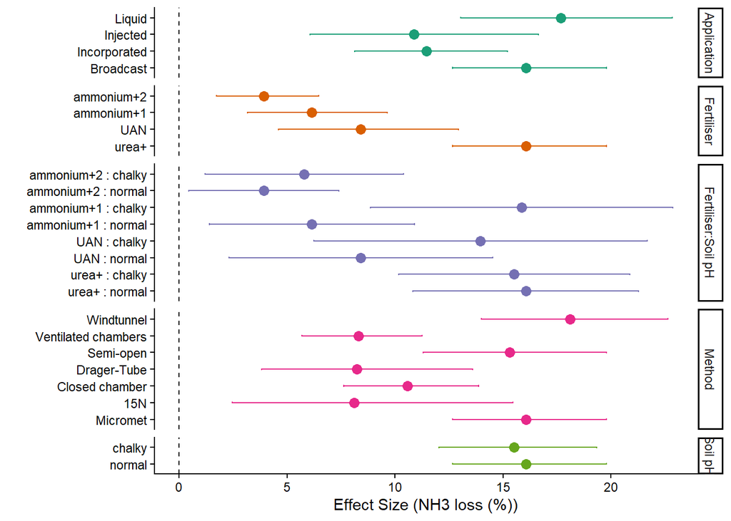

### Model LO5_Base model, pH, temperature, rainfall and Application rate

```
## Type III Analysis of Variance Table with Satterthwaite's method
##                          Sum Sq Mean Sq NumDF  DenDF F value    Pr(>F)
## Fertiliser               317.47 105.822     3 885.54 65.1870 < 2.2e-16 ***
## Application               27.76   9.253     3 865.53  5.6997 0.0007263 ***
## Method                    33.41   5.569     6 133.59  3.4305 0.0035024 **
## pH_cat                    33.01  33.009     1 901.89 20.3339 7.361e-06 ***
## Application.rate          18.51  18.513     1 801.95 11.4044 0.0007680 ***
## AirTemperature            10.73  10.728     1 898.22  6.6082 0.0103111 *
## Rain.mean                  8.47   8.471     1 900.08  5.2180 0.0225861 *
## Fertiliser:pH_cat         41.64  13.879     3 883.61  8.5497 1.338e-05 ***
## AirTemperature:Rain.mean   4.67   4.667     1 901.28  2.8750 0.0903110 .
## ---
## Signif. codes:  0 '***' 0.001 '**' 0.01 '*' 0.05 '.' 0.1 ' ' 1
```

```
## Linear mixed model fit by REML. t-tests use Satterthwaite's method [
## lmerModLmerTest]
## Formula: sqrt(NH3loss + 4) ~ Fertiliser + Application + Method + pH_cat +
##     Fertiliser:pH_cat + Application.rate + AirTemperature + Rain.mean +
##     AirTemperature * Rain.mean + (1 | Ref)
##    Data: NH3predict_mALL5
## Weights: Weight
## Control: lmerControl(optimizer = "bobyqa")
##
## REML criterion at convergence: 2552
##
## Scaled residuals:
##     Min      1Q  Median      3Q     Max
## -3.9032 -0.5653 -0.0458  0.5366  5.1138
##
## Random effects:
##  Groups   Name        Variance Std.Dev.
##  Ref      (Intercept) 0.7837   0.8853
##  Residual             1.6234   1.2741
## Number of obs: 923, groups:  Ref, 99
##
## Fixed effects:
##                                     Estimate Std. Error         df t value
## (Intercept)                        3.801e+00  2.556e-01  2.354e+02  14.871
## FertiliserUAN                     -1.033e+00  2.697e-01  8.996e+02  -3.831
## Fertiliserammonium+1              -1.302e+00  2.168e-01  8.938e+02  -6.006
## Fertiliserammonium+2              -1.647e+00  9.158e-02  8.786e+02 -17.983
## ApplicationIncorporated           -4.573e-01  1.186e-01  8.981e+02  -3.858
## ApplicationInjected               -2.619e-01  4.121e-01  8.917e+02  -0.636
## ApplicationLiquid                  2.325e-01  2.123e-01  8.299e+02   1.095
## Method15N                         -8.539e-01  5.271e-01  6.061e+02  -1.620
## MethodClosed chamber              -5.181e-01  2.942e-01  9.345e+01  -1.761
## MethodDrager-Tube                 -8.562e-01  3.981e-01  7.872e+01  -2.151
## MethodSemi-open                    2.971e-02  3.300e-01  1.134e+02   0.090
## MethodVentilated chambers         -9.151e-01  2.808e-01  2.183e+02  -3.258
## MethodWindtunnel                   1.956e-01  3.141e-01  1.333e+02   0.623
## pH_catchalky                      -1.251e-02  1.187e-01  8.863e+02  -0.105
## Application.rate                   3.160e-03  9.356e-04  8.019e+02   3.377
## AirTemperature                     1.766e-02  6.869e-03  8.982e+02   2.571
## Rain.mean                         -9.835e-02  4.306e-02  9.001e+02  -2.284
```

[output cut: 13 more lines]

```
## MethodClosed chamber              0.081542 .
## MethodDrager-Tube                 0.034553 *
## MethodSemi-open                   0.928417
## MethodVentilated chambers         0.001300 **
## MethodWindtunnel                  0.534531
## pH_catchalky                      0.916033
## Application.rate                  0.000768 ***
## AirTemperature                    0.010311 *
## Rain.mean                         0.022586 *
## FertiliserUAN:pH_catchalky        0.005899 **
## Fertiliserammonium+1:pH_catchalky 9.03e-06 ***
## Fertiliserammonium+2:pH_catchalky 0.118309
## AirTemperature:Rain.mean          0.090311 .
## ---
## Signif. codes:  0 '***' 0.001 '**' 0.01 '*' 0.05 '.' 0.1 ' ' 1
```

```
##
## Correlation matrix not shown by default, as p = 21 > 12.
## Use print(x, correlation=TRUE)  or
##     vcov(x)        if you need it
```

```
##            R2m       R2c
## [1,] 0.1917295 0.4548949
```

Model LO5 explains 45.49 % of the variation in the data (conditional R2), with the fixed effects explaining 19.17 % (marginal R2). Total observations = 923

### Model LO6_Base model, pH, temperature, non-linear rainfall and Application rate

```
## Type III Analysis of Variance Table with Satterthwaite's method
##                         Sum Sq Mean Sq NumDF  DenDF F value    Pr(>F)
## Fertiliser              317.94 105.981     3 885.54 65.3000 < 2.2e-16 ***
## Application              27.81   9.271     3 865.81  5.7121 0.0007139 ***
## Method                   33.61   5.602     6 133.50  3.4515 0.0033493 **
## pH_cat                   33.23  33.231     1 901.89 20.4753 6.848e-06 ***
## Application.rate         18.60  18.597     1 802.65 11.4587 0.0007462 ***
## AirTemperature            6.77   6.768     1 901.53  4.1698 0.0414402 *
## Rain.exp                  8.44   8.443     1 901.54  5.2024 0.0227879 *
## Fertiliser:pH_cat        41.41  13.802     3 883.53  8.5041 1.426e-05 ***
## AirTemperature:Rain.exp   4.50   4.502     1 901.96  2.7742 0.0961428 .
## ---
## Signif. codes:  0 '***' 0.001 '**' 0.01 '*' 0.05 '.' 0.1 ' ' 1
```

```
## Linear mixed model fit by REML. t-tests use Satterthwaite's method [
## lmerModLmerTest]
## Formula: sqrt(NH3loss + 4) ~ Fertiliser + Application + Method + pH_cat +
##     Fertiliser:pH_cat + Application.rate + AirTemperature + Rain.exp +
##     AirTemperature * Rain.exp + (1 | Ref)
##    Data: NH3predict_mALL6
## Weights: Weight
## Control: lmerControl(optimizer = "bobyqa")
##
## REML criterion at convergence: 2547.6
##
## Scaled residuals:
##     Min      1Q  Median      3Q     Max
## -3.9065 -0.5643 -0.0410  0.5408  5.1158
##
## Random effects:
##  Groups   Name        Variance Std.Dev.
##  Ref      (Intercept) 0.785    0.886
##  Residual             1.623    1.274
## Number of obs: 923, groups:  Ref, 99
##
## Fixed effects:
##                                     Estimate Std. Error         df t value
## (Intercept)                        5.371e-01  1.380e+00  8.989e+02   0.389
## FertiliserUAN                     -2.512e-01  2.705e-01  9.001e+02  -0.929
## Fertiliserammonium+1               1.655e-02  2.046e-01  8.571e+02   0.081
## Fertiliserammonium+2              -1.342e+00  1.869e-01  8.913e+02  -7.184
## ApplicationIncorporated           -4.580e-01  1.185e-01  8.980e+02  -3.863
## ApplicationInjected               -2.636e-01  4.121e-01  8.919e+02  -0.640
## ApplicationLiquid                  2.316e-01  2.123e-01  8.306e+02   1.091
## Method15N                         -8.517e-01  5.271e-01  6.056e+02  -1.616
## MethodClosed chamber              -5.160e-01  2.944e-01  9.339e+01  -1.753
## MethodDrager-Tube                 -8.559e-01  3.984e-01  7.869e+01  -2.148
## MethodSemi-open                    3.242e-02  3.301e-01  1.133e+02   0.098
## MethodVentilated chambers         -9.205e-01  2.809e-01  2.182e+02  -3.277
## MethodWindtunnel                   1.953e-01  3.142e-01  1.334e+02   0.622
## pH_catnormal                       8.277e-03  1.187e-01  8.859e+02   0.070
## Application.rate                   3.168e-03  9.357e-04  8.027e+02   3.385
## AirTemperature                     1.209e-01  5.919e-02  9.015e+02   2.042
## Rain.exp                           2.820e-01  1.236e-01  9.015e+02   2.281
```

[output cut: 13 more lines]

```
## MethodClosed chamber              0.082902 .
## MethodDrager-Tube                 0.034752 *
## MethodSemi-open                   0.921932
## MethodVentilated chambers         0.001220 **
## MethodWindtunnel                  0.535201
## pH_catnormal                      0.944402
## Application.rate                  0.000746 ***
## AirTemperature                    0.041440 *
## Rain.exp                          0.022788 *
## FertiliserUAN:pH_catnormal        0.006136 **
## Fertiliserammonium+1:pH_catnormal 9.29e-06 ***
## Fertiliserammonium+2:pH_catnormal 0.122577
## AirTemperature:Rain.exp           0.096143 .
## ---
## Signif. codes:  0 '***' 0.001 '**' 0.01 '*' 0.05 '.' 0.1 ' ' 1
```

```
##
## Correlation matrix not shown by default, as p = 21 > 12.
## Use print(x, correlation=TRUE)  or
##     vcov(x)        if you need it
```

# GLMM

```
## Analysis of Deviance Table (Type II Wald chisquare tests)
##
## Response: NH3loss
##                     Chisq Df Pr(>Chisq)
## Fertiliser        257.242  3  < 2.2e-16 ***
## Application        39.461  3  1.386e-08 ***
## Method             36.231  6  2.486e-06 ***
## pH_cat              6.059  1    0.01384 *
## Clay                2.212  1    0.13694
## AirTemperature     56.362  1  6.029e-14 ***
## Fertiliser:pH_cat  57.358  3  2.155e-12 ***
## ---
## Signif. codes:  0 '***' 0.001 '**' 0.01 '*' 0.05 '.' 0.1 ' ' 1
```

```
##  Family: tweedie  ( log )
## Formula:
## NH3loss ~ Fertiliser + Application + Method + pH_cat + Fertiliser:pH_cat +
##     Clay + AirTemperature + (1 | Ref)
## Dispersion:               ~Fertiliser + Application + Method + pH_cat
## Data: NH3predict_mALL
##
##       AIC       BIC    logLik -2*log(L)  df.resid
##    5541.4    5709.8   -2735.7    5471.4       873
##
## Random effects:
##
## Conditional model:
##  Groups Name        Variance Std.Dev.
##  Ref    (Intercept) 0.6928   0.8323
## Number of obs: 908, groups:  Ref, 99
##
## Conditional model:
##                                    Estimate Std. Error z value Pr(>|z|)
## (Intercept)                        2.415430   0.199280  12.121  < 2e-16 ***
## FertiliserUAN                     -0.626518   0.153402  -4.084 4.42e-05 ***
## Fertiliserammonium+1              -1.350686   0.165554  -8.159 3.39e-16 ***
## Fertiliserammonium+2              -1.937830   0.126638 -15.302  < 2e-16 ***
## ApplicationIncorporated           -0.687749   0.171054  -4.021 5.80e-05 ***
## ApplicationInjected               -0.992816   0.202696  -4.898 9.68e-07 ***
## ApplicationLiquid                 -0.143835   0.125416  -1.147  0.25144
## Method15N                         -0.557094   0.365691  -1.523  0.12766
## MethodClosed chamber              -0.705281   0.264175  -2.670  0.00759 **
## MethodDrager-Tube                 -1.047810   0.402261  -2.605  0.00919 **
## MethodSemi-open                   -0.169074   0.287005  -0.589  0.55580
## MethodVentilated chambers         -0.961922   0.204056  -4.714 2.43e-06 ***
## MethodWindtunnel                   0.248482   0.244794   1.015  0.31007
## pH_catchalky                      -0.046374   0.107936  -0.430  0.66745
## Clay                              -0.004922   0.003309  -1.487  0.13694
## AirTemperature                     0.036594   0.004874   7.507 6.03e-14 ***
## FertiliserUAN:pH_catchalky         0.720810   0.177690   4.057 4.98e-05 ***
## Fertiliserammonium+1:pH_catchalky  1.409253   0.241937   5.825 5.72e-09 ***
## Fertiliserammonium+2:pH_catchalky  1.076836   0.246371   4.371 1.24e-05 ***
## ---
## Signif. codes:  0 '***' 0.001 '**' 0.01 '*' 0.05 '.' 0.1 ' ' 1
##
## Dispersion model:
##                           Estimate Std. Error z value Pr(>|z|)
## (Intercept)                0.47821    0.14802   3.231 0.001235 **
## FertiliserUAN              0.93960    0.25354   3.706 0.000211 ***
## Fertiliserammonium+1      -0.31872    0.17431  -1.828 0.067476 .
## Fertiliserammonium+2       0.46263    0.13267   3.487 0.000489 ***
## ApplicationIncorporated    0.38863    0.14582   2.665 0.007694 **
## ApplicationInjected       -1.05778    0.45369  -2.331 0.019728 *
## ApplicationLiquid         -1.62844    0.19377  -8.404  < 2e-16 ***
## Method15N                 -2.39190    0.79168  -3.021 0.002517 **
## MethodClosed chamber      -0.16986    0.15855  -1.071 0.284028
## MethodDrager-Tube         -0.07477    0.18679  -0.400 0.688941
## MethodSemi-open           -0.30882    0.19479  -1.585 0.112879
## MethodVentilated chambers -0.31649    0.16438  -1.925 0.054179 .
## MethodWindtunnel          -0.10296    0.16694  -0.617 0.537401
## pH_catchalky              -0.04040    0.09933  -0.407 0.684233
## ---
## Signif. codes:  0 '***' 0.001 '**' 0.01 '*' 0.05 '.' 0.1 ' ' 1
```

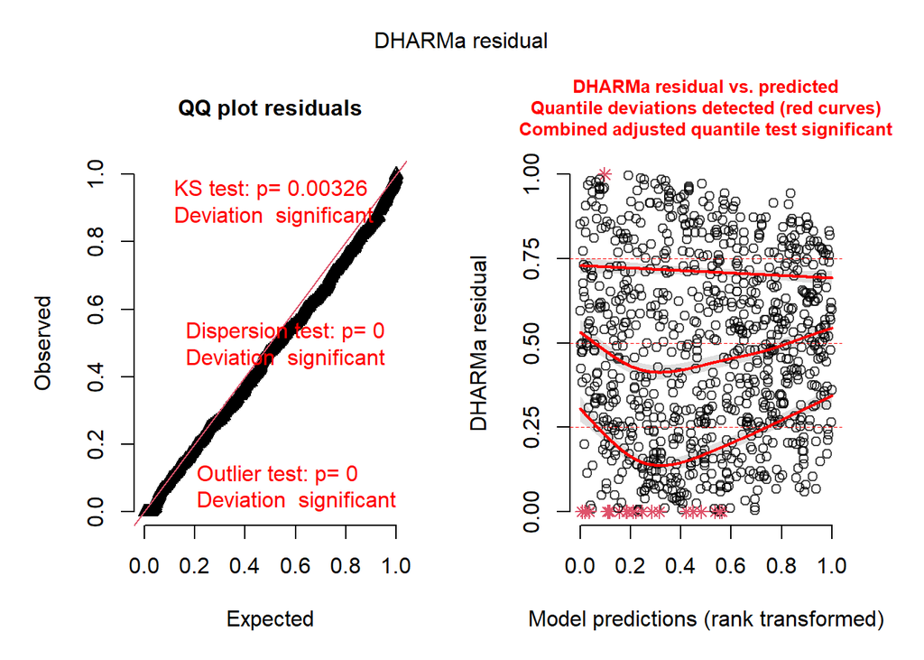

```
##                Factor               Level    Effect        SE  df  lower.CL
## 1          Fertiliser               urea+ 18.199407 3.1691996 Inf 12.936926
## 2          Fertiliser                 UAN  9.726668 2.2034957 Inf  6.239237
## 3          Fertiliser          ammonium+1  4.714785 1.1112925 Inf  2.970507
## 4          Fertiliser          ammonium+2  2.621008 0.5538349 Inf  1.732225
## 5         Application           Broadcast 18.199407 3.1691996 Inf 12.936926
## 6         Application        Incorporated  9.148960 2.2076292 Inf  5.701356
## 7         Application            Injected  6.743458 1.8253356 Inf  3.967138
## 8         Application              Liquid 15.761250 3.2768109 Inf 10.486325
## 9              Method            Micromet 18.199407 3.1691996 Inf 12.936926
## 10             Method                 15N 10.425915 3.3971748 Inf  5.505023
## 11             Method      Closed chamber  8.989957 1.8650280 Inf  5.986460
## 12             Method         Drager-Tube  6.382623 2.3797213 Inf  3.073506
## 13             Method           Semi-open 15.368423 3.5144602 Inf  9.816937
## 14             Method Ventilated chambers  6.955041 1.2811036 Inf  4.847415
```

[output cut: 37 more lines]

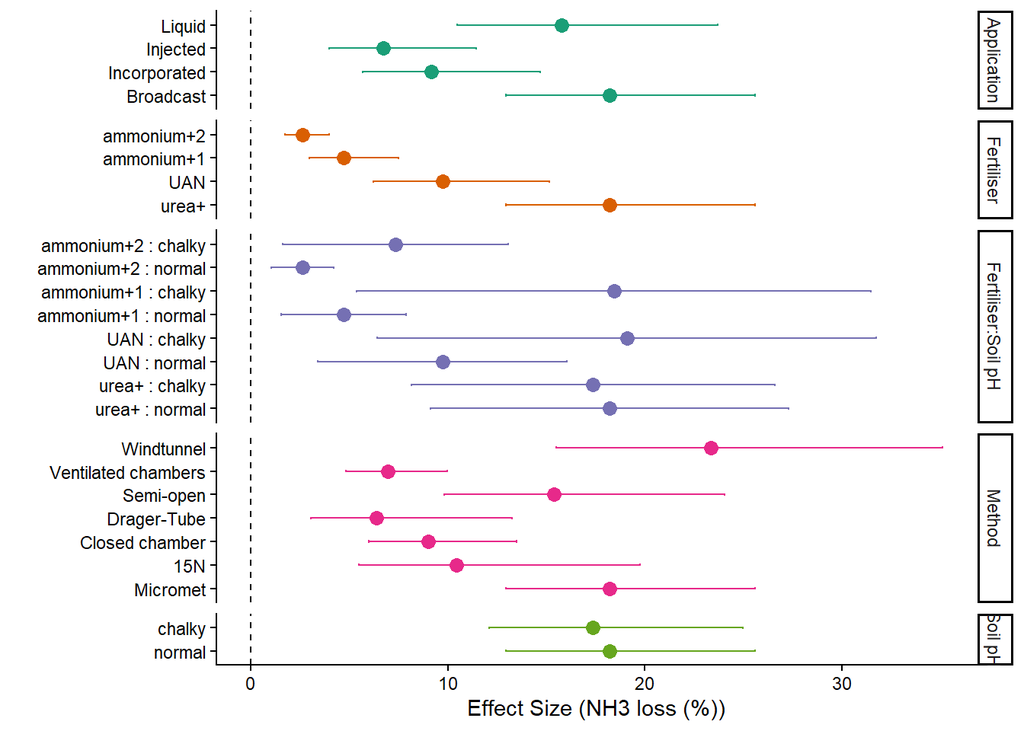

# References

Astivia, Oscar L. Olvera and Zumbo, Bruno D. (2019) “Heteroskedasticity in Multiple Regression Analysis: What it is, How to Detect it and How to Solve it with Applications in R and SPSS,” Practical Assessment, Research, and Evaluation: Vol. 24 , Article 1. DOI: https://doi.org/10.7275/q5xr-fr95

Douglas Bates, Martin Maechler, Ben Bolker, Steve Walker (2015). Fitting Linear Mixed-Effects Models Using lme4. Journal of Statistical Software, 67(1), 1-48. https://doi:10.18637/jss.v067.i01

Nakagawa, S, Schielzeth, H. (2013). A general and simple method for obtaining R^2 from Generalized Linear Mixed-effects Models. Methods in Ecology and Evolution 4: 133-142. https://doi.org/10.1111/j.2041-210x.2012.00261.x